# Question 1

Itai Assraf, Adam Uziel and Amir Zehavi

6/1/2021

```r
library(tidyverse)
library(rvest)
library(lubridate)
library(here)
library(glue)
library(countrycode)
library(dplyr, warn.conflicts = FALSE)
# Suppress summarise info
options(dplyr.summarise.inform = FALSE)
library(splitstackshape)
library(gridExtra)
library(data.table)
```

reading the raw wiki tables:

```r
cases_US_left <- read_csv(here::here("data", "Cases_US_final.csv"))
death_us <- read_csv(here::here("data", "Death_US_final.csv"))
```

```r
merged_covid_wiki <- cases_US_left %>%
  left_join(death_us,by=c("State","area","Date")) %>%
  mutate(num_deaths = replace_na(num_deaths,0))
```

```r
civiqs_polls <- read_csv(here::here("data", "civiqs_poll.csv"))
civiqs_polls<-civiqs_polls%>%
  rename(Date=date)

#change the format of the date.
civiqs_polls$Date<-as.Date(civiqs_polls$Date, format =  "%m/%d/%Y")
```

### Part 1:

#### **Explore The Covid Concern And Covid Cases 😷**

#### First Question-Seasons 🌈☀️❄️🍂

We had a lot of questions about Covid-19.

At the beginning of the pandemic, we heard from many researchers and doctors that the virus will most likely disappear when warmer days come.

One of the question was, how the seasons affect on the pandemic? Were the researchers and experts right? Will wee see less covid cases?

At first, we wanted to see the what months came the 10 days when there were the most dead.

```r
#which area has the most countries.
date_most_died<-merged_covid_wiki%>%
  group_by(Date)%>%
  mutate(sum_death=sum(num_deaths))%>%
  arrange(desc(sum_death))%>%
  select(area,Date,sum_death)%>%
  separate(Date, into = c("Year", "Month", "Day"), sep = "-")%>%
  distinct(Month,sum_death)%>%
  arrange(desc(sum_death))%>%
  head(n=10)

date_most_died
```

```
## # A tibble: 10 x 2
##    Month sum_death
##    <chr>     <dbl>
##  1 01         4137
##  2 01         4013
##  3 01         3916
##  4 01         3907
##  5 01         3865
##  6 01         3824
##  7 01         3787
##  8 01         3759
##  9 02         3735
## 10 01         3690
```

**Explanation**: We can see that from January(mainly) and February were the months when there were days with the most dead.

**Maybe,it could be connected to the seasons** ❔ **☀️/☔ days will affect** ❔

We will check the affect of each season on the proportion between the number of death to number of cases.

```r
#dividing the date to 3 parts
season_cases_death<-merged_covid_wiki %>%
    separate(Date, into = c("Year", "Month", "Day"), sep = "-")


#second-change tp numeric
season_cases_death$Month<-as.numeric(season_cases_death$Month)

#classify the months to season. 10-12 Fall, 1-3 Winter, 4-6 Spring, 7-9 Summer
season_cases_death<-season_cases_death %>%
  mutate(season = ifelse(Month %in% 10:12, "Fall",
                               ifelse(Month %in% 1:3, "Winter",
                                      ifelse(Month %in% 4:6, "Spring",
                                             "Summer"))))


#for each season check the sum of deaths
max_season_death_Cases<-season_cases_death %>%
  group_by(season) %>%
  select(season,num_deaths,num_cases)%>%
  mutate(sum_death=sum(num_deaths)) %>%
  mutate(sum_cases=sum(num_cases)) %>%
  distinct(season,sum_death,sum_cases)

#see the proportion.
proportion_season<-max_season_death_Cases%>%
  mutate(proportion=sum_death/sum_cases)%>%
  arrange(desc(proportion))

proportion_season
```

```
## # A tibble: 4 x 4
## # Groups:   season [4]
##   season sum_death sum_cases proportion
##   <chr>      <dbl>     <dbl>      <dbl>
## 1 Winter    191933   1054068     0.182
## 2 Fall      132087    837863     0.158
## 3 Spring    154338   1834458     0.0841
## 4 Summer     77752   1353104     0.0575
```

But, **what with areas (geographical location.**❔ Winter and summer change in each area. There are warmer/ colder areas.

We will check to each area, the proportion between the number of death to number of cases.

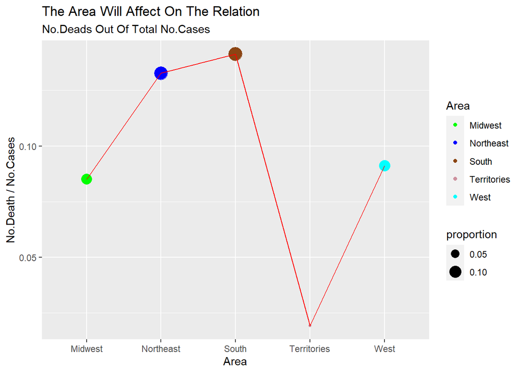

```r
#first part- checking how the area affect on the relation between the no deaths and no of cases.

#calculate the number of deaths for each area

cases_death_each_area<-season_cases_death%>%
  group_by(area)%>%
  mutate(sum_death=sum(num_deaths))%>%
  mutate(sum_cases=sum(num_cases))



# to check the relation between no. deaths to no. of cases
proportion_area<-cases_death_each_area%>%
  mutate(proportion=sum_death/sum_cases)%>%
  select(area,proportion)

area_g<-ggplot(proportion_area,aes(x=area,y=proportion),color=factor(area))+


 geom_point(aes(colour = factor(area),size = proportion))+

  geom_line(group = 'character',color="red")+

  labs(title='The Area Will Affect On The Relation',
       subtitle='No.Deads Out Of Total No.Cases',
       x='Area',
       y='No.Death / No.Cases',
       color='Area')+

  scale_color_manual(values = c("green", "blue", "chocolate4", "pink3","cyan"))

area_g
```

```r
# ggsave("area graph.png", plot = area_g,width=6.32,height = 3.91)
```

In the south we would expect fewer deaths relative to the number of cases, as there are warmer days, and higher temperatures relative to other areas.

One of the reasons is the winter may be very hard in summer is why “statistics are straightening out”. **Were the researchers really right?** 😕

We will therefore examine how the season in each area has affected this.

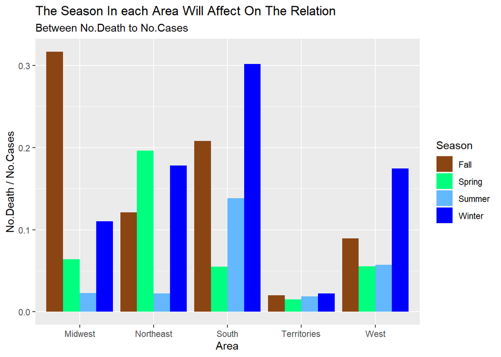

```r
#calculate the number of death,cases for each area and season
cases_death_each_area_season<-season_cases_death%>%
  group_by(area,season)%>%
  mutate(sum_death=sum(num_deaths))%>%
  mutate(sum_cases=sum(num_cases))


#calculate the relation between the num of deaths to num of cases.
proportion_area_season<-cases_death_each_area_season%>%
  mutate(proportion=sum_death/sum_cases)


graph_season_area<-ggplot(proportion_area_season,aes(area,proportion,fill=factor(season)))+

  geom_bar(stat='identity', position='dodge')+


  labs(title='The Season In each Area Will Affect On The Relation',
       subtitle='Between No.Death to No.Cases',
       x='Area',
       y='No.Death / No.Cases',
       fill='Season')+
  #correspond the colors to the seasons
  scale_fill_manual(values = c("chocolate4", "springgreen", "steelblue1", "blue"))

graph_season_area
```

```r
# ggsave("season_area.png", plot = graph_season_area,width=6.32,height = 3.91)
```

**The doctors were right** about this. ✔️

**THe seasons affect on the proportion between deaths and cases.**

About the south, we can see that the winter there, the hardest winter from all the areas, and the spring one of the most easier, the “statistics are straightening out”. ⬆️

#### **Second Question: Republicans 🔴🇺🇸**

**How the covid affect on the mood of different people with different opinions? Will we see more concern⁉️ When people took the pandemic seriously ⁉️**

To try to answer for those questions, at first, we check how number of cases affect on republicans and democrats.

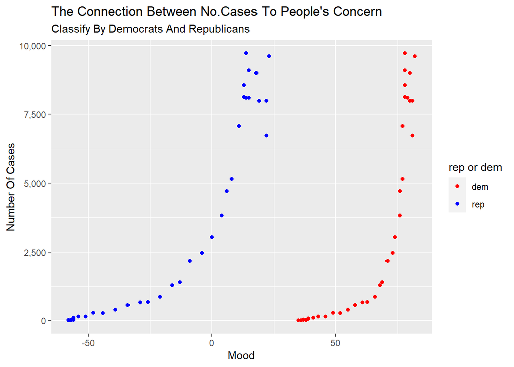

```r
#creating df of join between the cases to civiqs polls.

join_cases_death<-civiqs_polls%>%
  left_join(merged_covid_wiki,by='Date')%>%
  rename(Area=area)%>%
  select(rep,dem,num_cases,Date)%>%
  group_by(rep,dem,Date)%>%
  summarise(sum_cases=sum(num_cases)) #seeing the num of cases for each dem,                                       rep and the date.

#pivot! one columns with the values rep or dem. and the second column with the values of the mood of each party
pivot_data<-join_cases_death %>%
   pivot_longer(cols=c(dem,rep),
                names_to="rep_or_dem",
                values_to ="Current_Mood")

#writing the pivot table for using at the next part.
write_rds(pivot_data, file = here::here("data", "pivot_data.rds"))

#visual the difference or the similarity between the mood at each party
dem_rep<-ggplot(pivot_data,aes(Current_Mood,sum_cases,color=factor(rep_or_dem)))+

  geom_point(stat='identity')+


  labs(title="The Connection Between No.Cases To People's Concern",
       subtitle='Classify By Democrats And Republicans',
       x='Mood',
       y='Number Of Cases',
       color='rep or dem')+
  #correspond the colors to the parties
  scale_color_manual(values = c("red","blue"))+

    #tide the scale y column, to see the numbers in their normal display
  scale_y_continuous(name="Number Of Cases", labels = scales::comma)

dem_rep
```

```r
# ggsave("rep and dem.png", plot = dem_rep,width=6.32,height = 3.91)
```

**Explanation:** There is a correlation between no.cases to mood of people. More covid cases, more stress.

But, **When people understand that the pandemic is dangerous?** **Will we see different results about because people’s political opinion?**

```r
#see the average of number of cases before the republicans ans democrats went in stress.
before_stress<-pivot_data%>%
  filter(rep_or_dem=='rep' & Current_Mood<=0)%>%
  summarise(avg_not_stress=mean(sum_cases))


#see the average of number of cases when the republicans$democrats went in stress.
stress<-pivot_data%>%
  filter(rep_or_dem=='rep' & Current_Mood>0)%>%
  summarise(avg_stress=mean(sum_cases))


#the critical point, that from this point, we see the change between the mood of republicans (negative to positive)
the_value_in_calm<-pivot_data%>%
  filter(rep_or_dem=='rep' & Current_Mood==0)%>%
  select(sum_cases)%>%
  rename(critical_point=sum_cases)

#creating df from this details
df_stress<-data.frame(before_stress,stress,the_value_in_calm)
df_stress
```

```
##   avg_not_stress avg_stress critical_point
## 1       565.9231     7584.2           3017
```

**Explanation:** We can infer that at beginning, the republicans didn’t think that the pandemic is not dangerous. When they saw that there are 3017 covid cases they understood that it is really ❗

In contrary to Democrats, that from the start, they concerned from the covid-19.

Why?

Maybe because the Democrats didn’t trust on their president/disappoint from his conduct, and the Republicans believe in the president and trust him.

From this information, we can see that Republicans are more difficult to convince them that the pandemic is indeed dangerous (because they want the current president to continue in office)

**Therefore, we want to check how the mood of republicans changed day by day depending on the corona cases. When they** 😟 ↗️**/**↘️ **?**

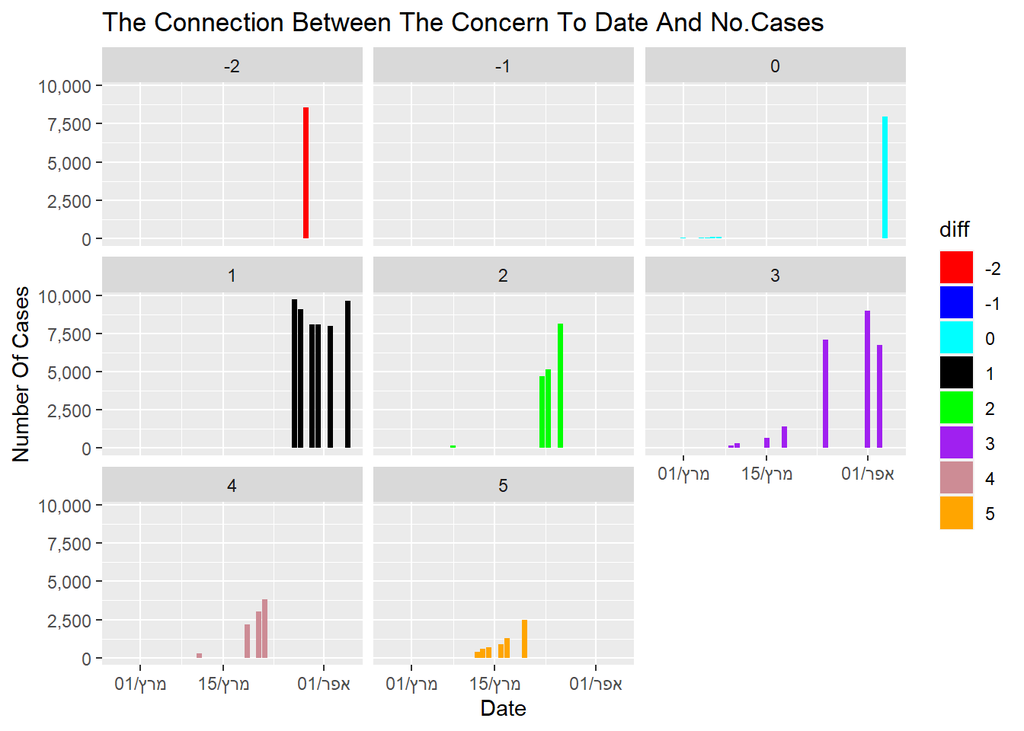

```r
#checking that if there is a connection between diff of the mood to the date

#we create a new column that calculate the different between the mood of rep at current date to his previous.
concern_change<-civiqs_polls%>%
  mutate(diff_rep = rep-lag(rep))

diff_previous<-concern_change%>%
  left_join(merged_covid_wiki,by='Date')%>%
  select(diff_rep,num_cases,Date)%>%
  group_by(Date)%>%
  mutate(sum_cases=sum(num_cases))%>%
  distinct(diff_rep,sum_cases,Date)%>%
  na.omit()



#visual-with geom bar. we will se the different on the diff that will affected by the Date and the number of cases

repp<-ggplot(diff_previous,aes(Date,sum_cases,fill=factor(diff_rep)))+

  geom_bar(stat='identity')+


  labs(title="The Connection Between The Concern To Date And No.Cases",
       x='Date',
       y='Number Of Cases',

       fill='diff')+
  #correspond the colors to the diff
  scale_fill_manual(values = c("red","blue","cyan","black","green","purple","lightpink3","orange"))+

  #tide the scale y column, to see the numbers in their normal display
      scale_y_continuous(name="Number Of Cases", labels = scales::comma)+

  #tide the x_scale of the dates. We will see the month and the day.
  scale_x_date(date_labels = "%b/%d")+

#dividing the graphs by the diff
  facet_wrap(~diff_rep)

repp
```

```r
#saving the plot.
#gsave("Date Cases Diff.png", plot = repp,width=6.32,height = 3.91)
```

**Explanation:** From this graph, we can see number of conclusions:

1️⃣: At the beginning of the pandemic (2 weeks), when were more covid cases, we see more concern.

2️⃣: After 2 weeks, we see more covid concern, more than the first 2 weeks, but less concern ❗

Why did this happen?

**We think that the answer is the power of habit. People get used quickly to things, even in a time of crisis .**

#### Third Question-Weekdays: 📅

During the pandemic, many doctors in Israel 🇮🇱 said that need to do a closure at weekends because could be a lot of corona cases, because many people will do trips or to meet their 👪/👦👧 and as a result they could be infected

As a result we want to check another important question, that if will we more covid cases at weekends or at the other days.

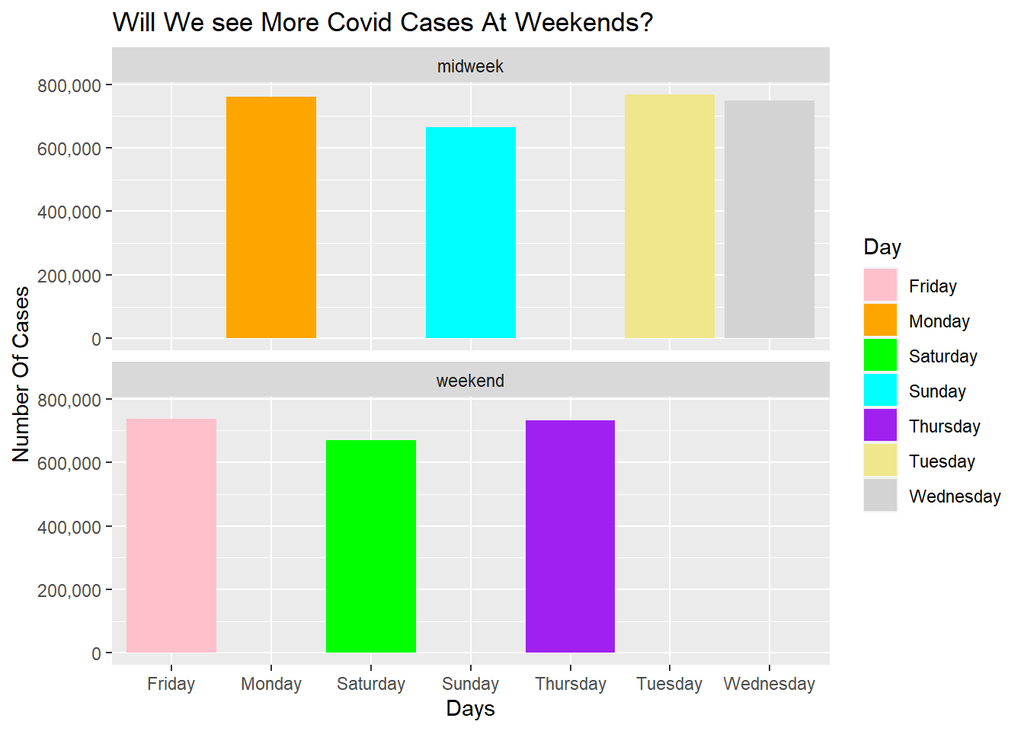

```r
#change the day to english
change_english<-Sys.setlocale("LC_TIME", "C")

#add columns with the day of week

merged_covid_wiki$weekdays<-strftime(merged_covid_wiki$Date,"%A")

#calculate the proportion for each day.
weekdays_set<-merged_covid_wiki%>%
  group_by(weekdays)%>%
  summarise(sum_cases=sum(num_cases))%>%
  distinct(weekdays,sum_cases)


weekends_days<-c("Saturday","Friday","Thursday")

#add colomn weekend or mid-week
weekdays_set<-weekdays_set%>%
  mutate(m_w= ifelse(weekdays %in% weekends_days, "weekend","midweek"))


days<-ggplot(weekdays_set,aes(weekdays,sum_cases,fill=factor(weekdays)))+

  #x axis the day and y axis the sum_Cases.
  geom_col()+


  labs(title="Will We see More Covid Cases At Weekends?",
       x='Days',
       y='Number Of Cases',

       fill='Day')+
  #correspond the colors to the diff
  scale_fill_manual(values = c("pink","orange","green","cyan","purple","khaki","lightgray"))+

  #see the numbers in y axis normal (800,000 and not 8e+6)
    scale_y_continuous(name="Number Of Cases", labels = scales::comma)+

  #divind for weekend and midweek
  facet_wrap(~m_w,ncol=1)

days
```

```r
# ggsave("days.png", plot = days,width=6.32,height = 3.91)
```

**Explanation:** We can see that at the midweeks there is more covid cases than at the weekends !! This is surprise ❗

**It’s in contrary the doctors’ opinion.**

But, the doctors can said that because many of meeting at the weekend they infected, and we will discover after ⏲️ (after few days,not immediately).

Because of the results, **we want to see how the concern of people changed in weekends, and how in midweeks.**

If it’s on weekend, we think that we will see less concern, because many people go to 🏖️, to family and not go to 📨.

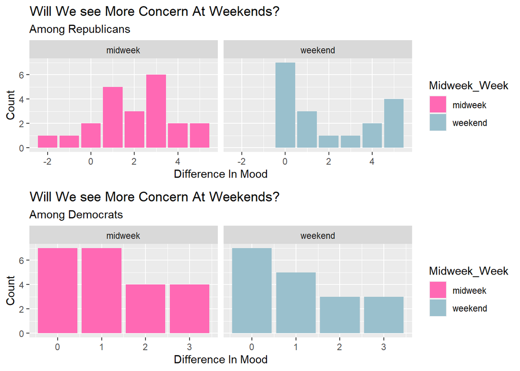

```r
#Add a columns of the days for each date
civiqs_polls$weekdays<-strftime(civiqs_polls$Date,"%A")

#the days in week
weekends_days<-c("Saturday","Friday","Thursday")

#the change of the concern at each day
concern_days<-civiqs_polls%>%
  mutate(diff_rep = rep-lag(rep))%>%
  mutate(diff_dem = dem-lag(dem))%>%
  na.omit()%>%
  mutate(m_w= ifelse(weekdays %in% weekends_days, "weekend","midweek"))%>%
  select(diff_rep,diff_dem,m_w)

#republicans change
rep_change<-ggplot(concern_days,aes(diff_rep,fill=m_w))+

  #x axis the day and y axis the sum_Cases.
 geom_histogram(position='dodge',alpha=0.7) +

                 stat_count()+


  labs(title="Will We see More Concern At Weekends?",
       subtitle ='Among Republicans',
       x='Difference In Mood',
       y='Count',
       fill='Midweek_Week')+

      scale_fill_manual(values = c("hotpink","lightblue3"))+

  facet_wrap(~m_w)

dem_change<-ggplot(concern_days,aes(diff_dem,fill=m_w))+

  #x axis the day and y axis the sum_Cases.
 geom_histogram(position='dodge',alpha=0.7) +

                 stat_count()+


  labs(title="Will We see More Concern At Weekends?",
       subtitle='Among Democrats',
       x='Difference In Mood',
       y='Count',
       fill='Midweek_Week')+

    scale_fill_manual(values = c("hotpink","lightblue3"))+


  facet_wrap(~m_w)



g<-grid.arrange(rep_change,dem_change,ncol=1)
```

```r
# ggsave("concern_weekdays.png", plot = g,width=6.32,height = 3.91)
```

**Explanation:** There is and interesting result.